# Analysis of factive verbs

jdegen

Aug 19, 2016

## Step 1: select stimuli for experiment

Set your path here and load some packages:

```r
setwd("/Users/titlis/cogsci/projects/esslli2016_corpuspragmatics/code_sheets/")
source("/Users/titlis/cogsci/projects/esslli2016_corpuspragmatics/factives/results/rscripts/helpers.R")
library(ggplot2)
theme_set(theme_bw())
```

Read the database into R and explore it.

```r
d = read.table("/Users/titlis/cogsci/projects/esslli2016_corpuspragmatics/factives/factives_corpus_search/results/swbdext.tab",sep="\t",header=T,quote="")
nrow(d)
```

```
## [1] 4705
```

```r
head(d)
```

```
##   Item_ID    Verb
## 1    89:5   think
## 2   118:5   think
## 3  178:59 thought
## 4   214:7   think
## 5  215:37   think
## 6  236:41   think
##                                                                                                                                                         Complement
## 1                                                  when she finally came to the realization that, you know, no, i can not, i can not take care of myself --n40242b
## 2                                                                                                                          that they, they had a great deal of, um
## 3                                                                                                                               --n404078 should be done --n40408b
## 4                                                                                          that when she passed away --n404c45 it was probably one of the greatest
## 5                                                                                                                                                      it would be
## 6 that what one thing that they were concerned --n405458 probably was the fact it wasn't necessarily, you know, like the quantity of care but the quality of, care
##                                                                                                                                                                                   Sentence
## 1                                                                 i think when she finally came to the realization that, you know, no, i can not, i can not take care of myself --n40242b.
## 2                                                                                                                                         i think that they, they had a great deal of, um,
## 3                                                                     and, uh, fortunately, we agreed, you know, on exactly, you know, what we thought --n404078 should be done --n40408b.
## 4                                                                                                     and i think that when she passed away --n404c45 it was probably one of the greatest,
## 5                                                                                                                                                           um, i, i, i think it would be,
## 6 and, um, i, i, i think that what one thing that they were concerned --n405458 probably was the fact it wasn't necessarily, you know, like the quantity of care but the quality of, care.
##   Environment Subject     VerbNiteID      CompNiteID
## 1                   i   sw2005_s54_2  sw2005_s54_503
## 2                   i   sw2005_s71_2  sw2005_s71_503
## 3                  we sw2005_s104_21 sw2005_s104_519
## 4                   i  sw2005_s125_3 sw2005_s125_503
## 5                   i sw2005_s126_14 sw2005_s126_514
## 6                   i sw2005_s137_16 sw2005_s137_514
```

```r
str(d)
```

```
## 'data.frame':    4705 obs. of  8 variables:
##  $ Item_ID    : Factor w/ 4705 levels "100037:5","100041:5",..: 4324 506 2369 2472 2476 2531 2630 2742 2770 2861 ...
##  $ Verb       : Factor w/ 35 levels "admit","admits",..: 32 32 35 32 32 32 32 32 32 32 ...
##  $ Complement : Factor w/ 4496 levels "","--n10077 will be doing well this year",..: 4328 2736 317 2882 1496 2875 2241 2485 3036 4471 ...
##  $ Sentence   : Factor w/ 4516 levels "--ing seems --n40001a to be a, a topic that --n40003d's going --n40004c to probably take about a generation --n40006b --n400072"| __truncated__,..: 2922 2532 762 312 4053 863 2477 3204 1367 2952 ...
##  $ Environment: Factor w/ 4 levels "","conditional",..: 1 1 1 1 1 1 1 1 1 1 ...
##  $ Subject    : Factor w/ 132 levels "","--n10f7c",..: 83 83 128 83 83 83 83 83 83 83 ...
##  $ VerbNiteID : Factor w/ 4705 levels "sw2005_s104_21",..: 9 10 1 2 3 4 5 6 7 8 ...
##  $ CompNiteID : Factor w/ 4705 levels "sw2005_s104_519",..: 9 10 1 2 3 4 5 6 7 8 ...
```

```r
summary(d)
```

```
##       Item_ID           Verb             Complement
##  100037:5 :   1   think   :3462   it is       :  19
##  100041:5 :   1   know    : 516   it's        :  18
##  100166:10:   1   thought : 251   that's true :  12
##  100181:10:   1   believe : 129   you're right:  11
##  10019:18 :   1   remember:  41   that's right:  10
##  10023:9  :   1   realize :  36   it          :   9
##  (Other)  :4699   (Other) : 270   (Other)     :4626
##                                                                                                                                                                                                                                                                        Sentence
##  i think it is.                                                                                                                                                                                                                                                            :   9
##  i think that's true.                                                                                                                                                                                                                                                      :   6
##  i think you're right.                                                                                                                                                                                                                                                     :   6
##  i think that's right.                                                                                                                                                                                                                                                     :   5
##  but i, i really think that in, in terms of like this, i'd, i think that it, it might not be such a bad thing. because, i don't know that anybody, w-, in-, i don't know that anybody would feel good, you know, like if you let someone like that loose in your community.:   4
##  i know in jamaica, uh, it think it's jamaica, i think it's jamaica, i know that they have, you know, crimes punishable by death,                                                                                                                                          :   4
##  (Other)                                                                                                                                                                                                                                                                   :4671
##       Environment      Subject              VerbNiteID
##             :3946   i      :4048   sw2005_s104_21:   1
##  conditional: 113   you    : 262   sw2005_s125_3 :   1
##  negation   : 460   they   :  88   sw2005_s126_14:   1
##  question   : 186   we     :  54   sw2005_s137_16:   1
##                     it     :  40   sw2005_s153_2 :   1
##                            :  32   sw2005_s174_12:   1
##                     (Other): 181   (Other)       :4699
##            CompNiteID
##  sw2005_s104_519:   1
##  sw2005_s125_503:   1
##  sw2005_s126_514:   1
##  sw2005_s137_514:   1
##  sw2005_s153_503:   1
##  sw2005_s174_513:   1
##  (Other)        :4699
```

Recode some variables (verb type, lemma).

```r
d$VerbType = as.factor(ifelse(d$Verb %in% c("believe","believed","thinking","thinks","thought","think"),"control",ifelse(d$Verb %in% c("saw","see","seeing","seemed","seems","seen","sees","sense"),"sense","factive")))
d$VerbLemma = as.factor(ifelse(d$Verb %in% c("believe","believed"),"believe",ifelse(d$Verb %in% c("thinking","thinks","thought","think"),"think",ifelse(d$Verb %in% c("saw","see","seeing"),"see",ifelse(d$Verb %in% c("know","knows","knew","known"),"know",ifelse(d$Verb %in% c("realize","realized"),"realize",ifelse(d$Verb %in% c("notice","noticed"),"notice","other")))))))
```

Output overview of cases.

```r
table(d$Verb,d$VerbType)
```

```
##
##              control factive sense
##   admit            0      17     0
##   admits           0       1     0
##   believe        129       0     0
##   believed         2       0     0
##   discover         0       3     0
##   discovered       0       4     0
##   foresaw          0       1     0
##   forget           0       1     0
##   forgotten        0       1     0
##   knew             0      34     0
##   know             0     516     0
##   knowing          0       7     0
##   known            0       1     0
##   knows            0      10     0
##   notice           0       9     0
##   noticed          0      17     0
##   realize          0      36     0
##   realized         0      13     0
##   realizes         0       1     0
##   realizing        0       4     0
##   recognize        0       6     0
##   remember         0      41     0
##   saw              0       0     2
##   see              0       0    35
##   seeing           0       0     1
##   seem             0       4     0
##   seemed           0       0     5
##   seems            0       0    34
##   seen             0       0     3
##   sees             0       0     1
##   sense            0       0     2
##   think         3462       0     0
##   thinking        34       0     0
##   thinks          17       0     0
##   thought        251       0     0
```

```r
table(d$VerbLemma,d$Environment)
```

```
##
##                conditional negation question
##   believe   98           7       22        4
##   know     476          19       55       11
##   notice    22           0        1        3
##   other    130           3        2        1
##   realize   30           4       14        1
##   see       29           4        4        1
##   think   3161          76      362      165
```

Restrict to those cases where subject is pronominal or “people”.

```r
d = droplevels(d[d$Subject %in% c("people","she","he","it","we","they","you","i"),])
d$SubjectPerson = as.factor(ifelse(d$Subject %in% c("i","we"), "1st",ifelse(d$Subject == "you","2nd",ifelse(d$Subject %in% c("it","he","she","people","they"),"3rd","other"))))

table(d$Verb,d$SubjectPerson,d$Environment)
```

```
## , ,  =
##
##
##               1st  2nd  3rd
##   admit         9    0    0
##   believe      81    1    2
##   believed      1    0    0
##   discover      1    0    0
##   discovered    3    0    1
##   foresaw       0    0    0
##   forgotten     1    0    0
##   knew         23    3    6
##   know        376   21   23
##   known         0    0    1
##   knows         0    0    6
##   notice        7    0    0
##   noticed      14    0    1
##   realize       9    3    2
##   realized      8    0    2
##   realizing     1    0    0
##   recognize     2    0    1
##   remember     38    1    0
##   saw           1    0    0
##   see          14    4    2
##   seem          0    0    2
##   seemed        0    0    4
##   seems         0    0   32
##   seen          2    0    0
##   sees          0    0    1
##   sense         1    1    0
##   think      2758   38   26
##   thinking     15    0    2
##   thinks        1    1    7
##   thought     204    3   30
##
## , ,  = conditional
##
##
##               1st  2nd  3rd
##   admit         0    0    0
```

[output cut: 84 more lines]

```
##   realizing     0    0    0
##   recognize     0    0    0
##   remember      0    0    0
##   saw           0    0    0
##   see           0    1    0
##   seem          0    0    0
##   seemed        0    0    0
##   seems         0    0    0
##   seen          0    0    0
##   sees          0    0    0
##   sense         0    0    0
##   think        11  146    2
##   thinking      0    1    0
##   thinks        0    0    0
##   thought       1    2    0
```

Select verbs

```r
see = droplevels(d[d$VerbLemma == "see",])
believe = droplevels(d[d$VerbLemma == "believe",])
think = droplevels(d[d$VerbLemma == "think",])
know = droplevels(d[d$VerbLemma == "know",])
realize = droplevels(d[d$VerbLemma == "realize",])

sampledsee = see %>%
  filter(Environment != "question") %>%
  filter(nchar(as.character(Complement)) > 12) %>%
  group_by(Environment) %>%
  sample_n(.,2)
sampledsee = as.data.frame(sampledsee)
sampledsee
```

```
##     Item_ID Verb
## 1 100957:13  see
## 2  105078:8  see
## 3  43219:23  see
## 4  96908:52  see
## 5 107158:12  see
## 6 128658:42  see
##                                                                                Complement
## 1       that there's, there's a different way of life and those families are really close
## 2 that it will be a very long time, probably, before i subscribe to any magazines at home
## 3                                                              it's a problem in the yard
## 4                                                               that they should stop her
## 5                                  that it would work for probably the majority of people
## 6                                             that, it, it, it can change it very quickly
##                                                                                                  Sentence
```

[output cut: 20 more lines]

```r
nrow(sampledsee)
```

```
## [1] 6
```

```r
sampledthink = think %>%
  filter(nchar(as.character(Complement)) > 12) %>%
  group_by(Environment) %>%
  sample_n(.,2)
sampledthink = as.data.frame(sampledthink)
sampledthink
```

```
##      Item_ID  Verb
## 1  20216:150 think
## 2    28783:5 think
## 3 107167:117 think
## 4  164471:95 think
## 5   30149:26 think
## 6   38260:12 think
## 7    9106:30 think
## 8   24556:12 think
##                                                                                                                                                          Complement
## 1                                                                                                              they need --n4007c7 to manage it a little bit better
## 2                        they feel this is going --n4016a0 to be an effortless sweatless way, to get in shape, without having --n4016eb to spend anything --n4016fe
## 3                                                                                                                                         if we could really budget
## 4                                                                                                                  they should be eliminated --n4031a8 from society
## 5                                                                  we've gone that far mumblex, --n402929 to pay it in ad-, you know, in advance before we spend it
```

[output cut: 30 more lines]

```r
nrow(sampledthink)
```

```
## [1] 8
```

```r
sampledbelieve = believe %>%
  filter(nchar(as.character(Complement)) > 12) %>%
  group_by(Environment) %>%
  sample_n(.,2)
sampledbelieve = as.data.frame(sampledbelieve)
sampledbelieve
```

```
##     Item_ID    Verb
## 1 151868:12 believe
## 2 174116:29 believe
## 3  57393:74 believe
## 4  12472:41 believe
## 5  19289:12 believe
## 6   5244:23 believe
## 7   34213:7 believe
## 8  34214:23 believe
##                                                                                                                                                                                                         Complement
## 1                                                                                                                                                                             --n401a58 they will be in tents also
## 2                                                                                                                                                        they suggested that judges should be doing the sentencing
## 3                                                                                                                                                                                                 it was --n407800
## 4                                                                                                                                                                 a majority of democrats may even have opposed it
## 5 that he, in this first pass around, you know, --n404799 being the first one --n4047b4 to really turn things around or attempt --n4047d7 to is going --n4047ee to be allowed --n404801 to get away with it either
```

[output cut: 30 more lines]

```r
nrow(sampledbelieve)
```

```
## [1] 8
```

```r
sampledknow = know %>%
  filter(nchar(as.character(Complement)) > 12) %>%
  group_by(Environment) %>%
  sample_n(.,4)
sampledknow = as.data.frame(sampledknow)
sampledknow
```

```
##      Item_ID Verb
## 1   41851:71 know
## 2   45539:36 know
## 3    75618:5 know
## 4   30792:17 know
## 5   93863:97 know
## 6   30079:84 know
## 7    2746:43 know
## 8    2473:37 know
## 9   18725:12 know
## 10 163965:12 know
## 11  45105:17 know
## 12 124158:25 know
## 13   5250:20 know
## 14  89300:12 know
```

[output cut: 70 more lines]

```r
nrow(sampledknow)
```

```
## [1] 16
```

```r
sampledrealize = realize %>%
  filter(nchar(as.character(Complement)) > 12) %>%
  filter(Environment != "question") %>%
  group_by(Environment) %>%
  sample_n(.,4)
sampledrealize = as.data.frame(sampledrealize)
sampledrealize
```

```
##      Item_ID     Verb
## 1    7150:34  realize
## 2  145371:10 realized
## 3   36984:32  realize
## 4    1100:43 realized
## 5  166967:27  realize
## 6  113018:67  realize
## 7  169350:34  realize
## 8   70930:73 realized
## 9   63941:12  realize
## 10  63955:12  realize
## 11 100276:30  realize
## 12   4431:14  realize
##                                                                                                                                                                                                                           Complement
## 1                                                                                                                                                                                                               anything is going on
```

[output cut: 50 more lines]

```r
nrow(sampledrealize)
```

```
## [1] 12
```

Combine all the sampled cases and write them to a stimulus file.

```r
library(jsonlite)
library(dplyr)

merged = bind_rows(sampledsee,sampledthink,sampledbelieve,sampledknow,sampledrealize) %>%
  mutate(NoThatComplement=gsub("^that ","",Complement,perl=T)) %>%
  mutate(StrippedComplement=gsub("--n[a-zA-Z0-9]*( |\\.|,|'|$)","",NoThatComplement,perl=T),StrippedSentence = gsub("--n[a-zA-Z0-9]*( |\\.|,|'|$)","",Sentence,perl=T)) %>%
  select(Item_ID,StrippedComplement,StrippedSentence,VerbType) %>%
  rename(id=Item_ID,complement=StrippedComplement,sentence=StrippedSentence,stimType=VerbType)
merged = as.data.frame(merged)

writeOutJSON <- toJSON(merged,pretty=T)
write(writeOutJSON, "/Users/titlis/cogsci/projects/esslli2016_corpuspragmatics/factives/factives_experiment/js/stimuli.json")
```

## Step 2: analyze projection data

```r
pd = data.frame()
temp = list.files("/Users/titlis/cogsci/projects/esslli2016_corpuspragmatics/factives/results/data/projection_data")
for (i in 1:length(temp)) {
  raw = fromJSON(paste("/Users/titlis/cogsci/projects/esslli2016_corpuspragmatics/factives/results/data/projection_data/",temp[i],sep=""))
  td = raw$trials
  subj = raw$subject_information
  td$language = subj$language
  td$enjoyment = subj$enjoyment
  td$asses = subj$asses
  td$age = subj$age
  td$gender = subj$gender
  td$education = subj$education
  td$comments = subj$comments
  td$participant = i
  pd = bind_rows(pd,td)
}
pd = as.data.frame(pd)
pd[sapply(pd, is.character)] <- lapply(pd[sapply(pd, is.character)],as.factor)
pd$participant = as.factor(as.character(pd$participant))
```

Because we didn’t record all information from the original database in the experiment, we need to merge that information back in by matching the TGrep2 item IDs.

```r
row.names(d) = d$Item_ID
pd$subject = d[as.character(pd$id),]$Subject
pd$verb = d[as.character(pd$id),]$Verb
pd$environment = d[as.character(pd$id),]$Environment
pd$environment = as.character(pd$environment)
pd[pd$environment == "",]$environment = "main"
pd$environment = as.factor(as.character(pd$environment))
pd$subjectperson = d[as.character(pd$id),]$SubjectPerson
summary(pd)
```

```
##       trial_type     response              id
##  projection:225   Min.   :0.0000   152345:18:  8
##                   1st Qu.:0.4900   2746:43  :  8
##                   Median :0.8200   96908:52 :  8
##                   Mean   :0.6687   93863:97 :  7
##                   3rd Qu.:0.9700   100957:13:  6
##                   Max.   :1.0000   106577:7 :  6
##                                    (Other)  :182
##                                                                                                                                                                                                                                                sentence
##  and, you know, if she wanted to go to combat, i do not see that they should stop her.                                                                                                                                                             :  8
##  if when they're meeting with the engineers who they know are going to be dressed down  if they come in, in, you know, a six hundred dollar three piece suit, it's going to make the people they're meeting with feel very uncomfortable, you know,:  8
##  so what else do you think is important.                                                                                                                                                                                                           :  8
##  i think that's the basic point of it, is i'm not, i, i don't enjoy it if i know that it's exercise,                                                                                                                                               :  7
##  and i know she's eating the right things,                                                                                                                                                                                                         :  6
##  and they've also see that there's, there's a different way of life and those families are really close.                                                                                                                                           :  6
##  (Other)                                                                                                                                                                                                                                           :182
##                                           complement    stim_type
##  are going to be dressed down                  :  8   control: 64
##  is important                                  :  8   factive:130
##  they should stop her                          :  8   sense  : 31
##  it's exercise                                 :  7
##  i needed that                                 :  6
##  i'm not going to be doing anything for a while:  6
##  (Other)                                       :182
##     language   enjoyment asses     age        gender    education comments
##         : 25   -1:125    Yes:225     :25   Female:150   -1: 50    :225
##  Dutch  : 50   1 : 75              24:25   Male  : 75   3 : 50
##  English: 25   2 : 25              27:50                4 :125
##  German :100                       29:25
##  Russian: 25                       31:50
##                                    32:50
##
##   participant    subject          verb         environment subjectperson
##  1      :25   i      :133   know    :76   conditional:71   1st:137
##  2      :25   you    : 49   realize :41   main       :65   2nd: 49
##  3      :25   they   : 28   think   :31   negation   :53   3rd: 39
##  4      :25   he     :  6   see     :28   question   :36
##  5      :25   people :  5   believe :21
##  6      :25   we     :  4   realized:13
##  (Other):75   (Other):  0   (Other) :15
```

```r
nrow(pd)
```

```
## [1] 225
```

### Understand your participant population

Get unique participant information.

```r
pinfo = unique(pd[,c("language","enjoyment","asses","age","gender","comments")])
nrow(pinfo)
```

```
## [1] 9
```

Is everyone a native speaker of English?

```r
table(pinfo$language)
```

```
##
##           Dutch English  German Russian
##       1       2       1       4       1
```

Did people love or hate the experiment?

```r
table(pinfo$enjoyment)
```

```
##
## -1  1  2
##  5  3  1
```

Did people understand the experiment?

```r
table(pinfo$asses)
```

```
##
## Yes
##   9
```

How old are our participants?

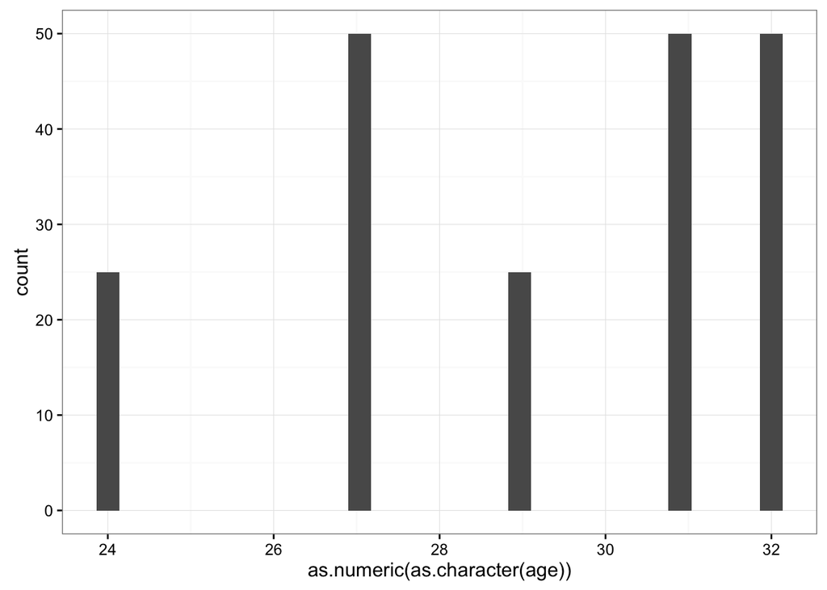

```r
ggplot(pd, aes(x=as.numeric(as.character(age)))) +
  geom_histogram()
```

What is the gender of our participants?

```r
table(pinfo$gender)
```

```
##
## Female   Male
##      6      3
```

What did participants have to say about the experiment?

```r
pinfo$comments
```

```
## [1]
## Levels:
```

### Visualize your data

Plot the overall distribution of responses.

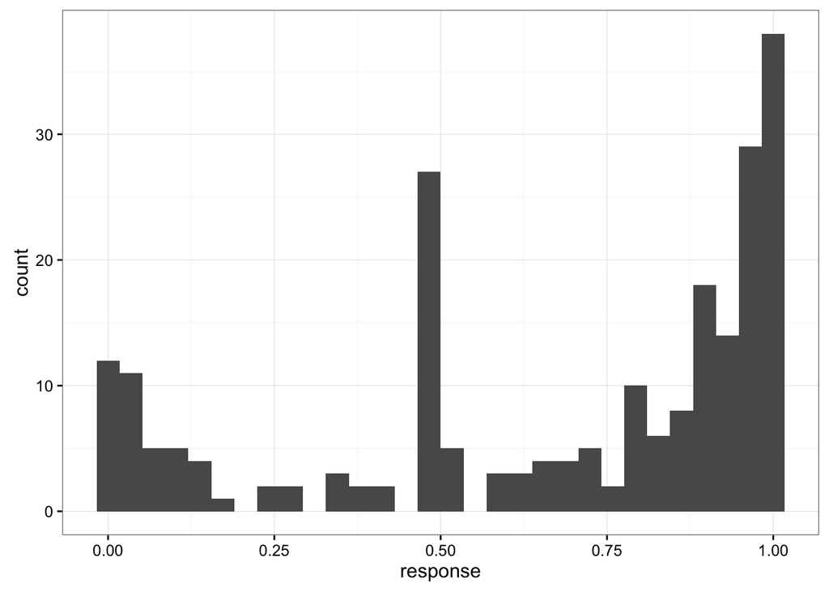

```r
ggplot(pd, aes(x=response)) +
  geom_histogram()
```

This histogram includes cognitive factives (know, realize), sense factives (see), and non-factivs (believe, think). Let’s group histograms by these three groups.

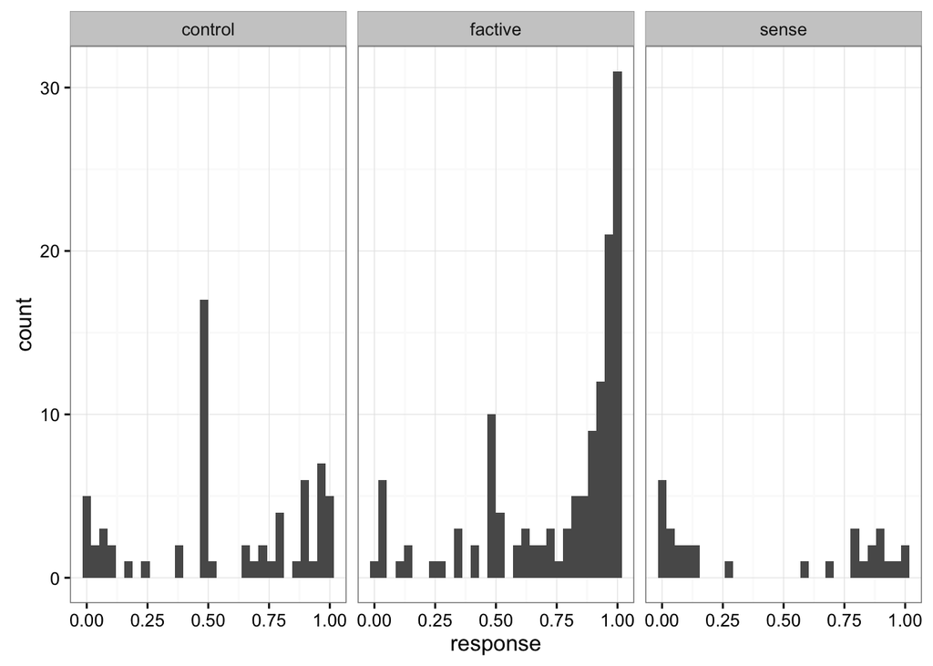

```r
ggplot(pd, aes(x=response)) +
  geom_histogram() +
  facet_wrap(~stim_type)
```

Do the distributions vary by subject person?

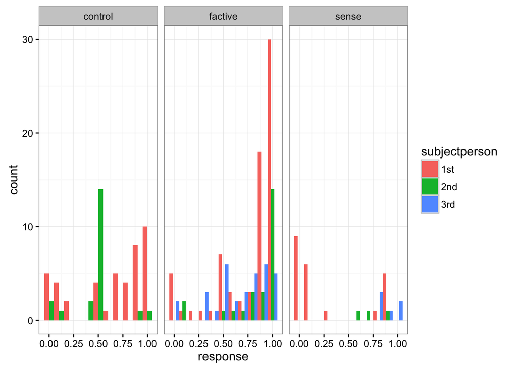

```r
ggplot(pd, aes(x=response,fill=subjectperson)) +
  geom_histogram(position="dodge",binwidth=.1) +
  facet_wrap(~stim_type)
```

Do the distributions vary by environment? Let’s re-order the environment factor levels so “main clause” is in the top row.

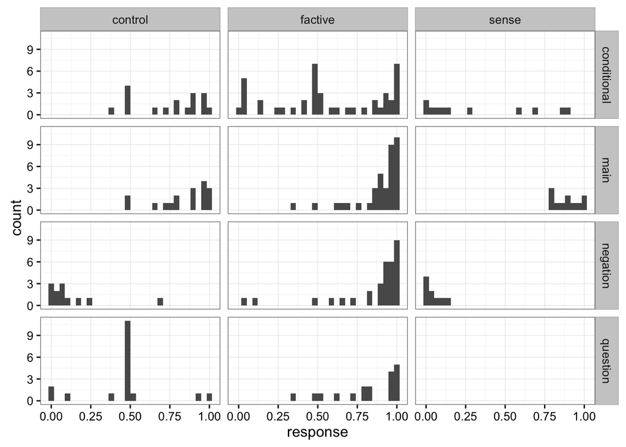

```r
pd$env = factor(x=pd$environment, levels=c("main","negation","conditional","question"))
ggplot(pd, aes(x=response)) +
  geom_histogram(position="dodge") +
  facet_grid(environment~stim_type)
```

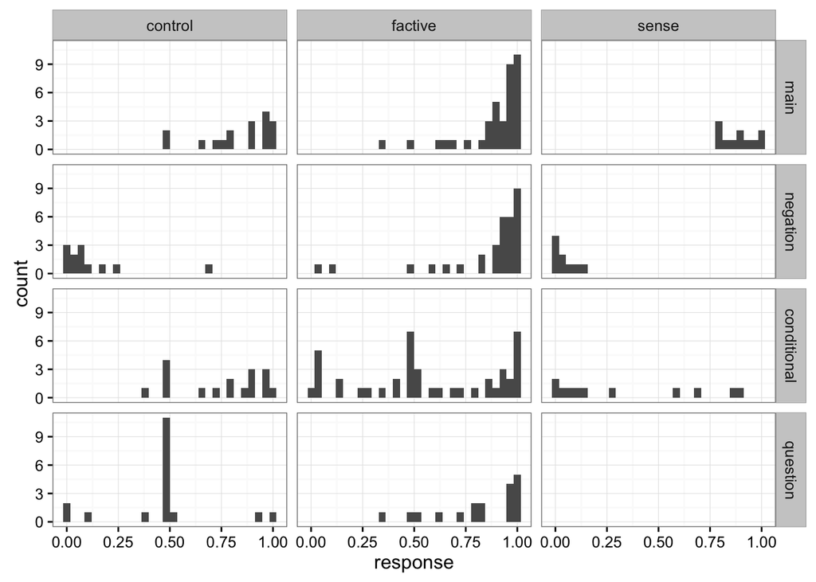

```r
ggplot(pd, aes(x=response)) +
  geom_histogram(position="dodge") +
  facet_grid(env~stim_type)
```

Do the distributions vary both by environment and by subject person?

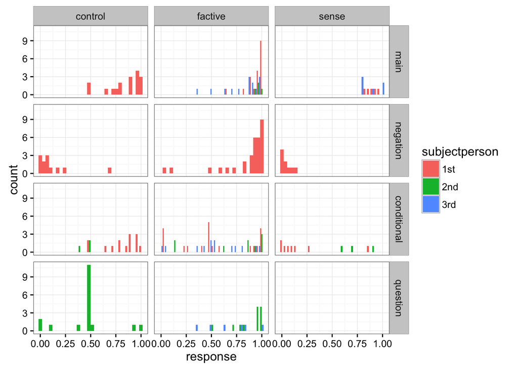

```r
ggplot(pd, aes(x=response,fill=subjectperson)) +
  geom_histogram(position="dodge") +
  facet_grid(env~stim_type)
```

This visualization is getting unwieldy. There are too many facets with too many variables being plotted, all the while the numbers of observations in each cell are unbalanced. Let’s try to compress this information into a simpler form.

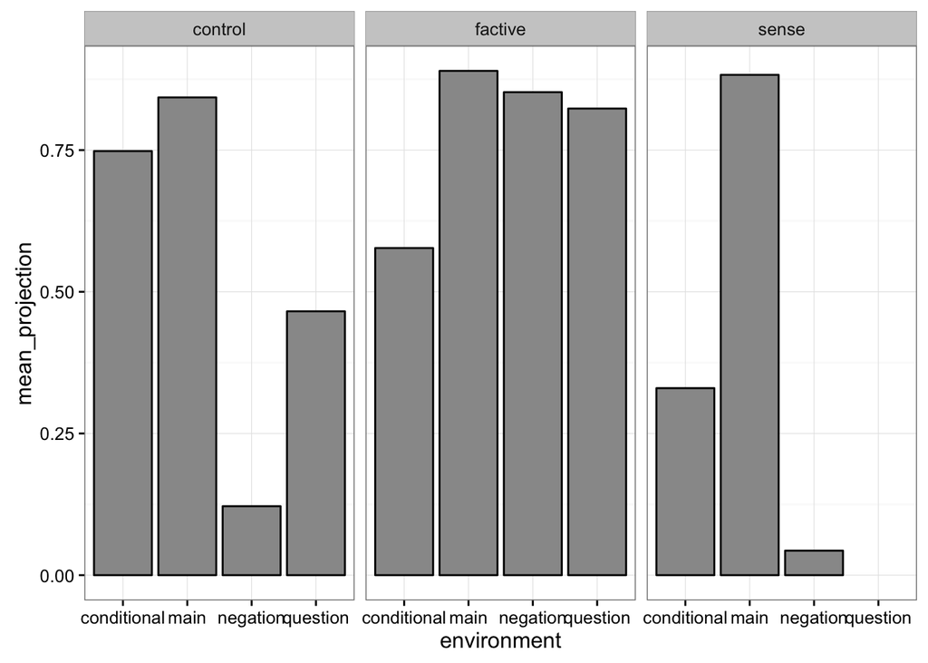

```r
agr = pd %>%
  group_by(environment,stim_type) %>%
  summarise(mean_projection=mean(response))
ggplot(agr, aes(x=environment,y=mean_projection)) +
  geom_bar(stat="identity",position="dodge",color="black",fill="gray60") +
  facet_wrap(~stim_type)
```

This is easier to read, but we lost a lot of information about variability in each condition. Let’s instead plot condition means with bootstrapped 95% confidence intervals.

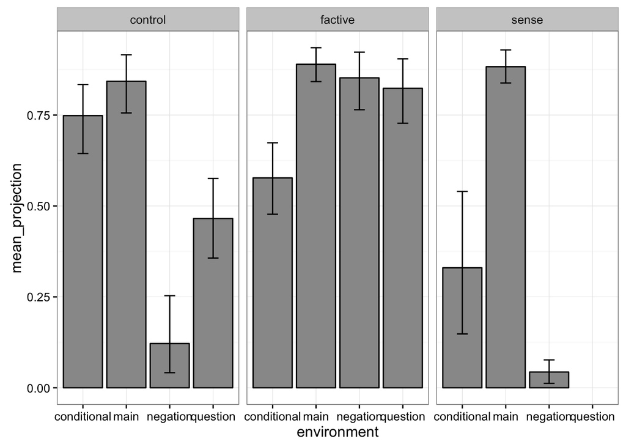

```r
agr = pd %>%
  group_by(environment,stim_type) %>%
  summarise(mean_projection=mean(response),ymin=mean(response)-ci.low(response),ymax=mean(response)+ci.high(response))
ggplot(agr, aes(x=environment,y=mean_projection)) +
  geom_bar(stat="identity",position="dodge",color="black",fill="gray60") +
  geom_errorbar(aes(ymin=ymin,ymax=ymax),width=.25) +
  facet_wrap(~stim_type)
```

Let’s add the subject information back in.

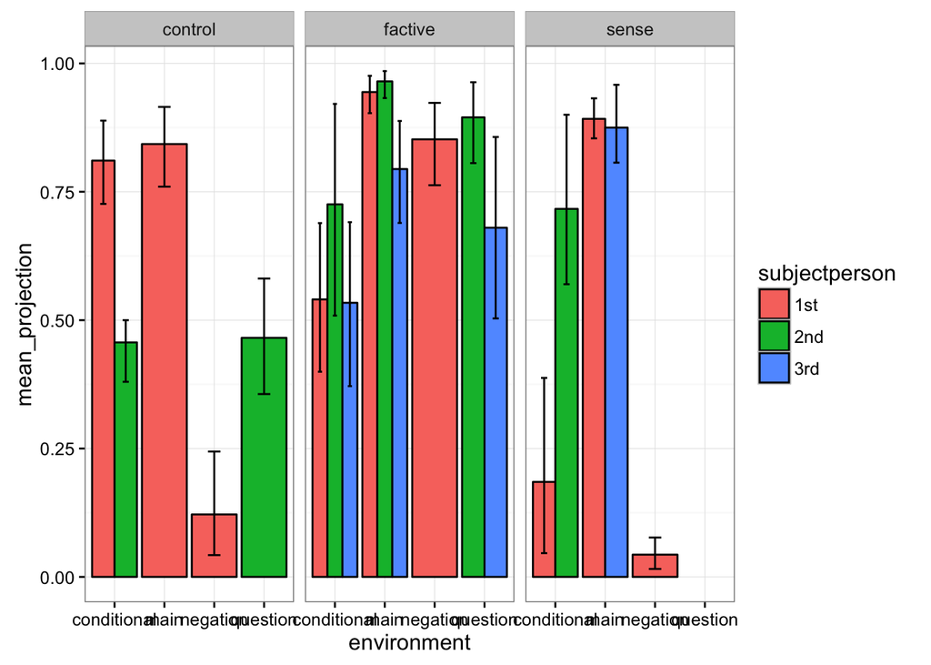

```r
agr = pd %>%
  group_by(environment,subjectperson,stim_type) %>%
  summarise(mean_projection=mean(response),ymin=mean(response)-ci.low(response),ymax=mean(response)+ci.high(response))
dodge = position_dodge(.9)
ggplot(agr, aes(x=environment,y=mean_projection,fill=subjectperson)) +
  geom_bar(stat="identity",position=dodge,color="black") +
  geom_errorbar(aes(ymin=ymin,ymax=ymax),width=.25,position=dodge) +
  facet_wrap(~stim_type)
```

This looks ugly. Let’s try plotting points instead and make the x axis labels more readable.

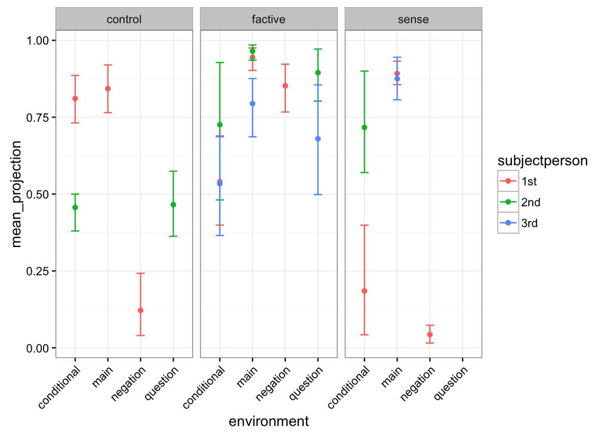

```r
agr = pd %>%
  group_by(environment,subjectperson,stim_type) %>%
  summarise(mean_projection=mean(response),ymin=mean(response)-ci.low(response),ymax=mean(response)+ci.high(response))
ggplot(agr, aes(x=environment,y=mean_projection,color=subjectperson)) +
  geom_point() +
  geom_errorbar(aes(ymin=ymin,ymax=ymax),width=.25) +
  facet_wrap(~stim_type) +
  theme(axis.text.x = element_text(angle=45,vjust=1,hjust=1))
```

Does complement length matter?

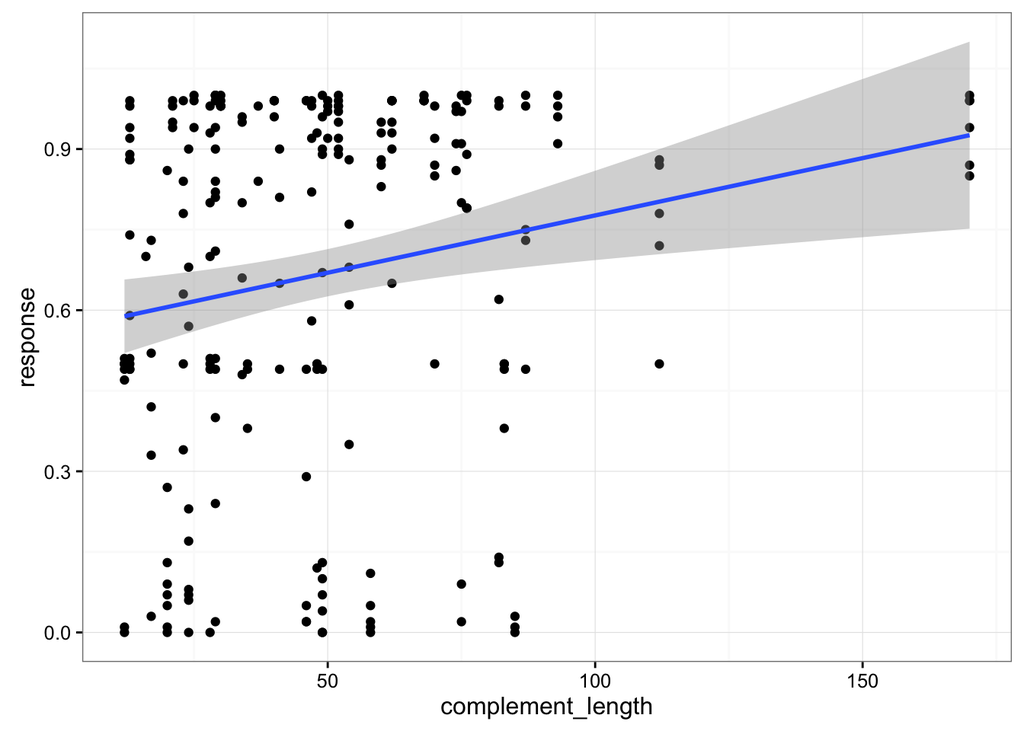

```r
pd$complement_length = nchar(as.character(pd$complement))
ggplot(pd, aes(x=complement_length,y=response)) +
  geom_point() +
  geom_smooth(method="lm")
```

Does complement length matter differently for different verbs?

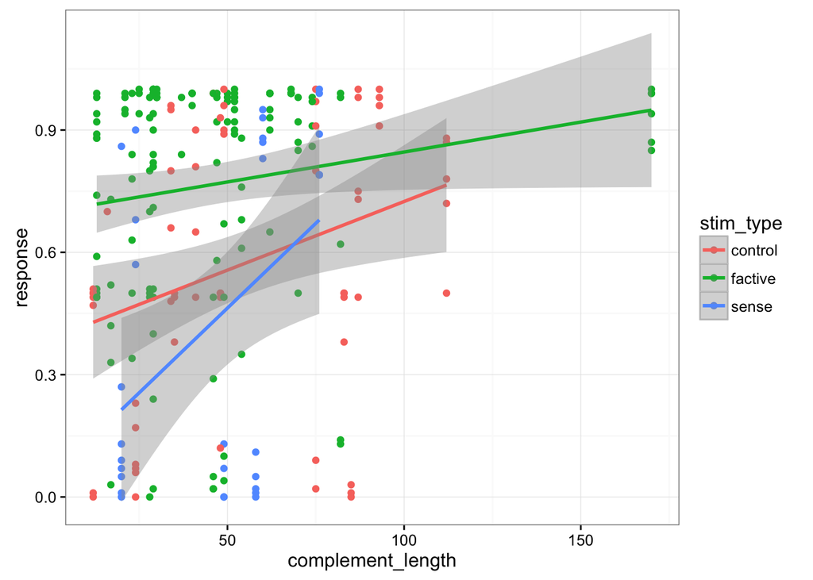

```r
ggplot(pd, aes(x=complement_length,y=response,color=stim_type)) +
  geom_point() +
  geom_smooth(method="lm")
```